# Probabilidad en R: Conceptos

prof. dr. J. Zavala

2023-09-22

https://rpubs.com/hllinas/R_Exp-Omega-Evento

[output not shown]

# PROBABILIDAD EN R

## Experimento, espacio muestral y evento

**Dr. rer. nat. Humberto LLinás Solano** Departamento de Matemáticas y Estadística, Universidad del Norte (Barranquilla, Colombia)

hllinas@uninorte.edu.co

[Biographical sketch](https://rpubs.com/hllinas/Bio_Sketch)

26/08/21

### Abstract

La teoría mencionada puede revisarse en el capítulo 2 de mis notas de clase que aparecen en el siguiente documento: [1.1. Estadística básica](https://rpubs.com/hllinas/R_NotasClase). En [Rpubs:: toc](https://rpubs.com/hllinas/toc) se pueden ver otros documentos de posible interés.

### 0 Preparación del entorno

Los paquetes `prob` y `repmis` no están disponibles desde CRAN, por lo que requieren un procedimiento alterno de instalación. Por ello, se ha creado el breve script en R titulado [R_Prob_Condicional_prerrequisito.R](https://github.com/jzavalar/probabilidad/blob/main/codigo/9.5_Probabilidad-en-R_Probabilidad-condicional.Rmd) que pemite instalarlos y preparar el ambiente para que funcione el tutorial. Ambos paquetes de instalan desde GitHub con el paquete `remotes` y `devtools`. Adicionalmente, se instalan el paquete `rio`, que sirve para preparar los datos de su fuente original, aunque en este repositorio, incluye una copia del repositorio `Datos Publicos` del dr. Humberto LLinás.

profe J. Zavala (JZ)

```r
library(prob)
```

### 1 Paquetes

En R podemos encontrar diversas funciones para ello:

```
`expand.grid` en el paquete `base`.
`combn` en el paquete `combinat`.
`permsn`, `tosscoin`, etc., en el paquete `prob`.
```

Para nuestros cálculos, utilizaremos la siguiente librería:

```r
#A) Para analizar experimentos estadísticos
library(combinat)
library(prob)
```

### 2 Experimento

Todo experimento se puede clasificar como se ilustra en la figura de abajo:

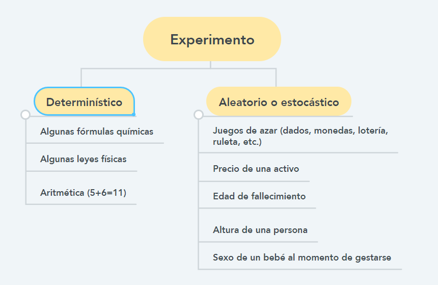

### 3 Espacio muestral

Teóricamente se simbolizará con $\Omega$. Revisaremos algunos ejemplos para encontrar los elementos de este conjunto.

#### 3.0.1 Ejemplo: Lanzar monedas

Considere el experimento aleatorio de lanzar n veces una moneda. Los resultados elementales son H (head, cara) y T (tail, sello). Con la librería “prob”, Podemos hallar los elementos del espacio muestral con la función “tosscoin” (lanzamiento de monedas):

```r
#A) Espacio muestral con n=1 lanzamiento de una moneda
tosscoin(1)
```

```
##   toss1
## 1     H
## 2     T
```

```r
#B) Espacio muestral con n=2 lanzamientos de una moneda
tosscoin(2)
```

```
##   toss1 toss2
## 1     H     H
## 2     T     H
## 3     H     T
## 4     T     T
```

```r
#C) Espacio muestral con n=3 lanzamientos de una moneda
tosscoin(3)
```

```
##   toss1 toss2 toss3
## 1     H     H     H
## 2     T     H     H
## 3     H     T     H
## 4     T     T     H
## 5     H     H     T
## 6     T     H     T
## 7     H     T     T
## 8     T     T     T
```

Para determinar el número de elementos que tiene el espacio muestral $\Omega$ y el de la muestra, se puede utilizar la función “dim”:

```r
#D) Espacio muestral con n=10 lanzamientos de una moneda
Omega <- tosscoin(10)

#E) Tamaños de Omega y de la muestra
dim(Omega)
```

```
## [1] 1024   10
```

#### 3.0.2 Ejemplo: Lanzar dados

Ahora considere el experimento aleatorio de lanzar n veces un dado. Los resultados elementales son 1, 2, 3,4, 5 y 6. Con la librería `prob` podemos hallar los elementos del espacio muestral con la función `rolldie()` (lanzamiento de dados):

```r
#F) Espacio muestral con n=2 lanzamientos de un dado
Omega<- rolldie(2)
Omega
```

```
##    X1 X2
## 1   1  1
## 2   2  1
## 3   3  1
## 4   4  1
## 5   5  1
## 6   6  1
## 7   1  2
## 8   2  2
## 9   3  2
## 10  4  2
## 11  5  2
## 12  6  2
## 13  1  3
## 14  2  3
```

[output cut: 22 more lines]

```r
#G) Tamaño de la muestra
dim(Omega)
```

```
## [1] 36  2
```